# Chicago Bulls Shot Brief

Isaac Dhyanchand

2025-11-03

# Chicago Bulls Shot Profile (2014–2024)

### Key Findings

**Figure 1** Season-by-season shot chart animation (Bulls, 2014–2024)

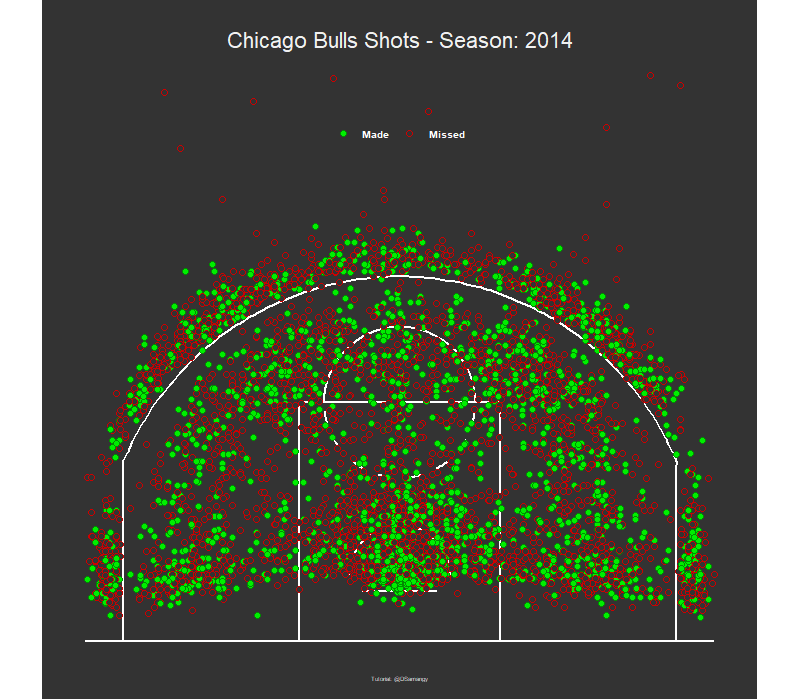

**Findings from Figure 1**

**Figure 2.** Bulls Zone Efficiency and Distribution of Shots

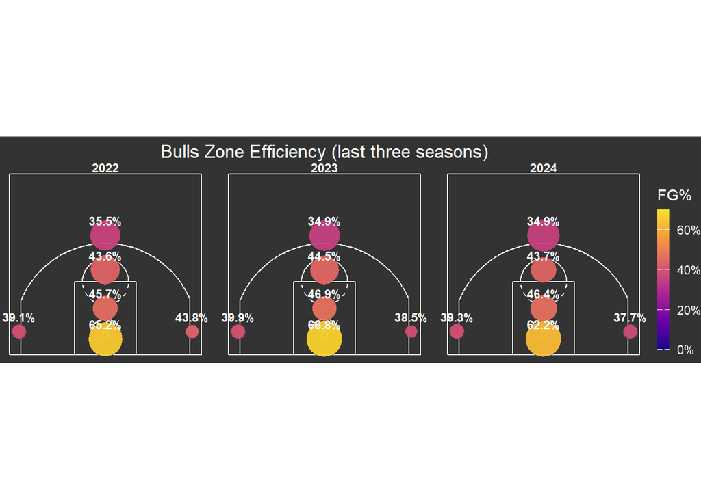

**Findings from Figure 2.**

- We can see a slight decrease in the mid-range shots volume from 2022-2024.
- Overall shot distribution and percentages have remained relatively the same over the last 3 years.
- Corner threes show solid efficiency but limited usage compared to other zones. -Visual emphasis shows clear focus on rim attempts and top-of-the-key three pointers.

**Figure 3.** Field-goal percentage by zone and season

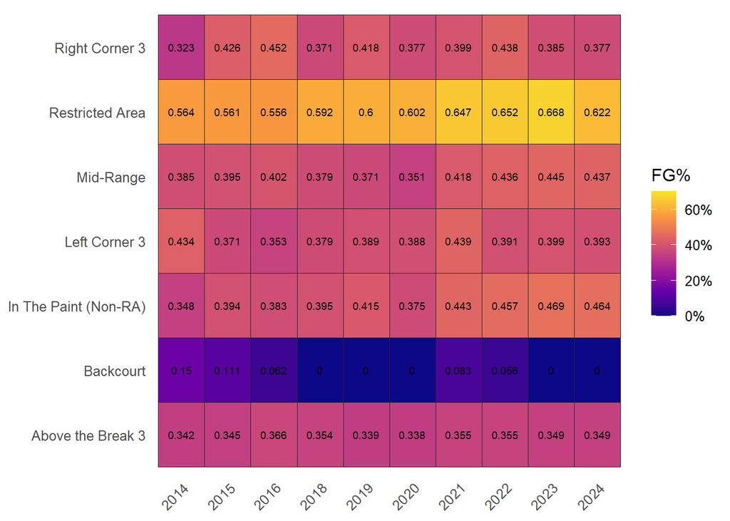

**Findings from Figure 3.**

- Highest percentage shots came from the Restricted Area.
- Midrange and in the paint percentages have increased fairly consistently since 2021.
- Three point percentages have not changed much over time.

**Figure 4.** Shot Attempts by Zone Over Time

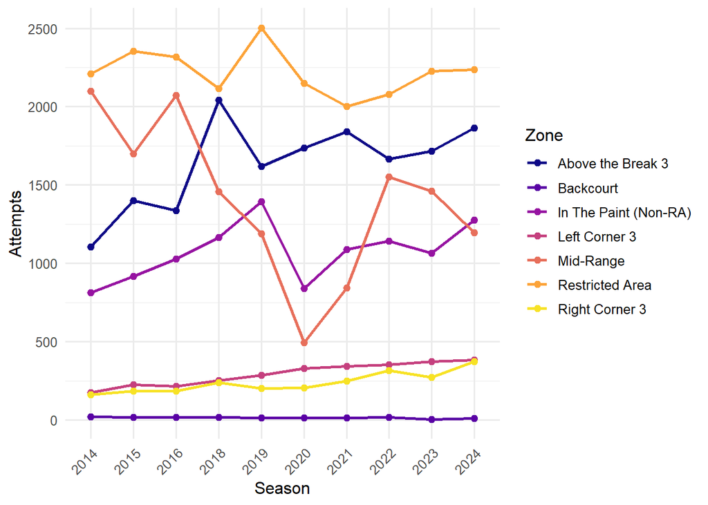

**Findings from Figure 4.**

- There is a fairly constant increase in the amount of three-point shots attempted.
- Mid-range shots seemed to have generally decreased since 2014.
- Restricted Area shots have consistently had the most volume in each year.
- Corner three’s are not popular shots

**Summary Takeaways**

- Shot efficiency remained stable across the past decade, with most value coming from the restricted area and above the break threes.
- Three-point attmept share has grown modestly, reflecting modern offensive changes.
- Defensive emphasis should focus on rim protection and limiting above the break threes.